# KetSDA weekly attendance over time

James R. Milks

06 November 2021

# Introduction

Weekly attendance at Kettering SDA Church has fluctuated with time. Here I present the results of an analysis of attendance patterns since 2002.

# In-person vs Online

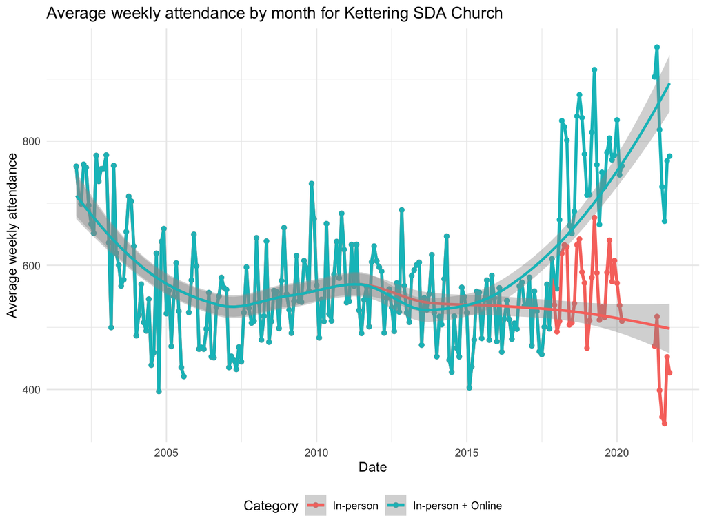

Since 2017, the online audience has increased in size and percentage of the total whereas in-person attendance has declined (mostly due to COVID).

# In-person vs Online

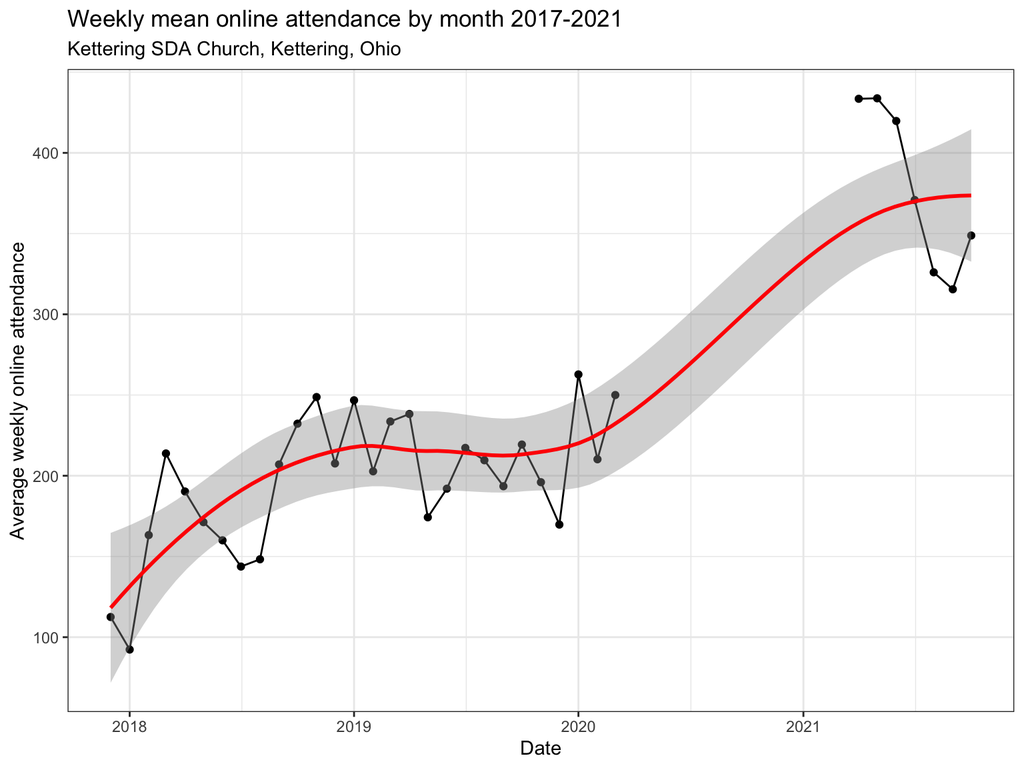

# In-person vs Online

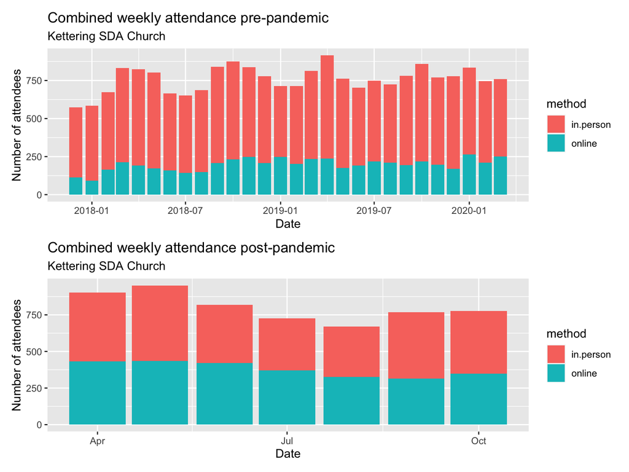

# In-person vs Online

- February 2019 - February 2020 + In-person attendance averaged 569.28 per week + Online attendance averaged 209.22 per week + Average total weekly attendance was 778.5.
- Since April 2021 + Total church attendance has averaged 803.55 per week + In-person attendance averaged 424.65 + Online attendance averaged 378.9

In-person attendance is down 144.64 but an increase of 169.69 in online attendance has made up for the loss of in-person attendance.

# In-person vs Online

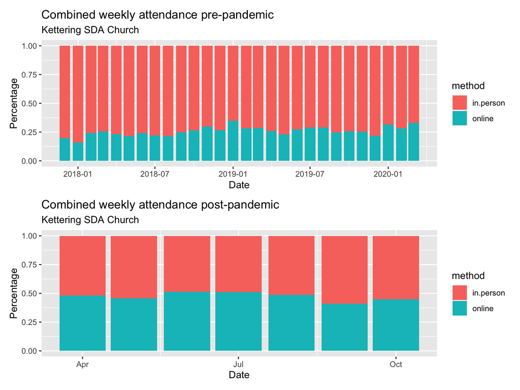

Before the pandemic, an average of 26.92% of our weekly audience came from our online ministry. Since reopening, however, 47.51% of our weekly audience has been online.

# In-person vs Online

- I created an interactive dashbaord to track in-person and online attendance.
- Find it at [https://jrmilks.shinyapps.io/KetSDAweeklyattendance/][https://jrmilks.shinyapps.io/KetSDAweeklyattendance/]

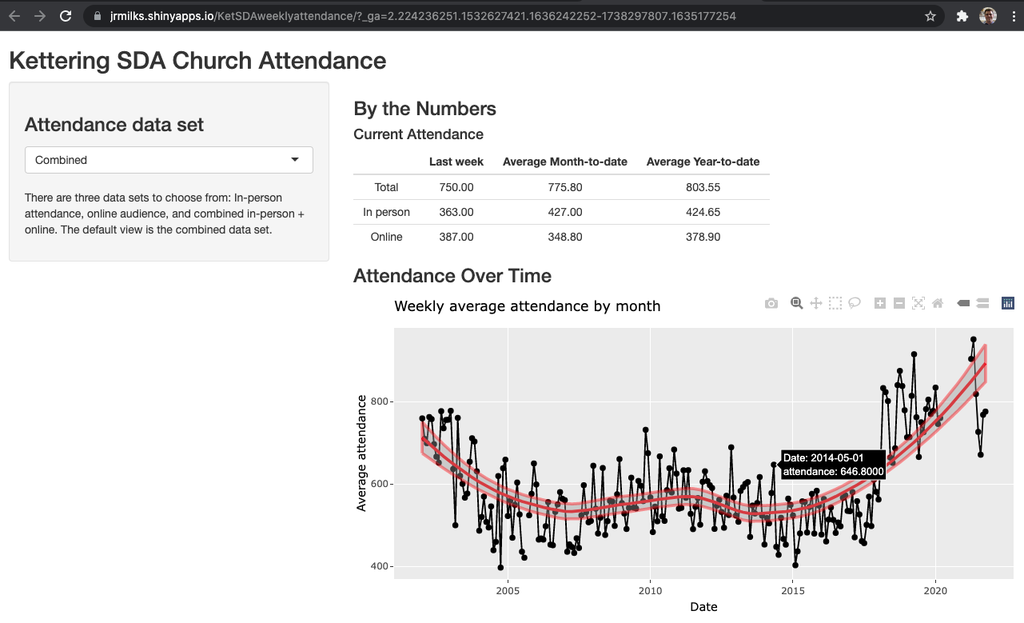

# Additional analysis